# Hello R

Shikyna William

Data 2401

### Load packages

```r
library(tidyverse)
library(datasauRus)
```

### Exercise 1

The datasaurus_dozen dataset contains 1,846 rows and 3 columns.

There are 3 variables in this dataset are:

- dataset : indicates which dataset the data are from
- x : x-values
- y : y-values

### Exercise 2

First let’s plot the data in the dino dataset:

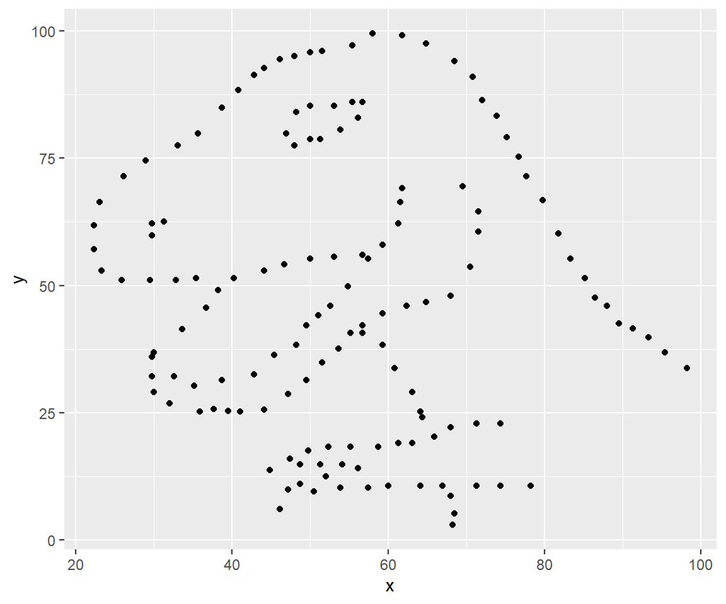

```r
dino_data <- datasaurus_dozen %>%
  filter(dataset == "dino")
ggplot(data = dino_data, mapping = aes(x = x, y = y)) +
  geom_point()
```

And next calculate the correlation between `x` and `y` in this dataset:

```r
dino_data %>%
  summarize(r = cor(x, y))
```

```
## # A tibble: 1 × 1
##         r
##     <dbl>
## 1 -0.0645
```

### Exercise 3

First let’s plot the data in the star dataset:

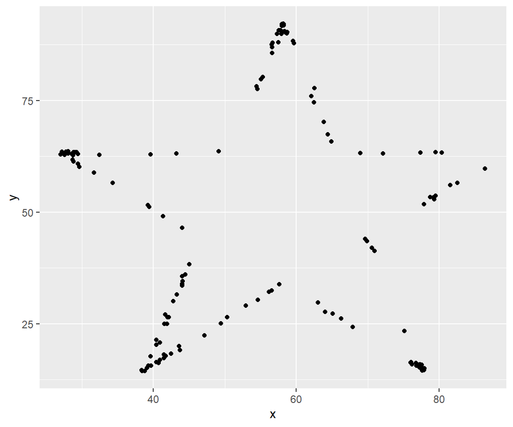

```r
star_data <- datasaurus_dozen %>%
  filter(dataset == "star")
ggplot(data = star_data, mapping = aes(x = x, y = y)) +
  geom_point()
```

And next calculate the correlation between `x` and `y` in this dataset:

```r
star_data %>%
  summarize(r = cor(x, y))
```

```
## # A tibble: 1 × 1
##         r
##     <dbl>
## 1 -0.0630
```

### Comparison of “Star” dataset with “Dino” data set:

There is not much difference in the **correlation** value (both close to **0**) of the two data sets, however the shapes are drastically different.

- The `"dino"` dataset forms a **dinosaur shape**.
- The `"star"` dataset forms a **star shape**.

This highlights the importance of **visualizing data** rather than relying only on correlation coefficients.

### Exercise 4

First let’s plot the data in the circle dataset:

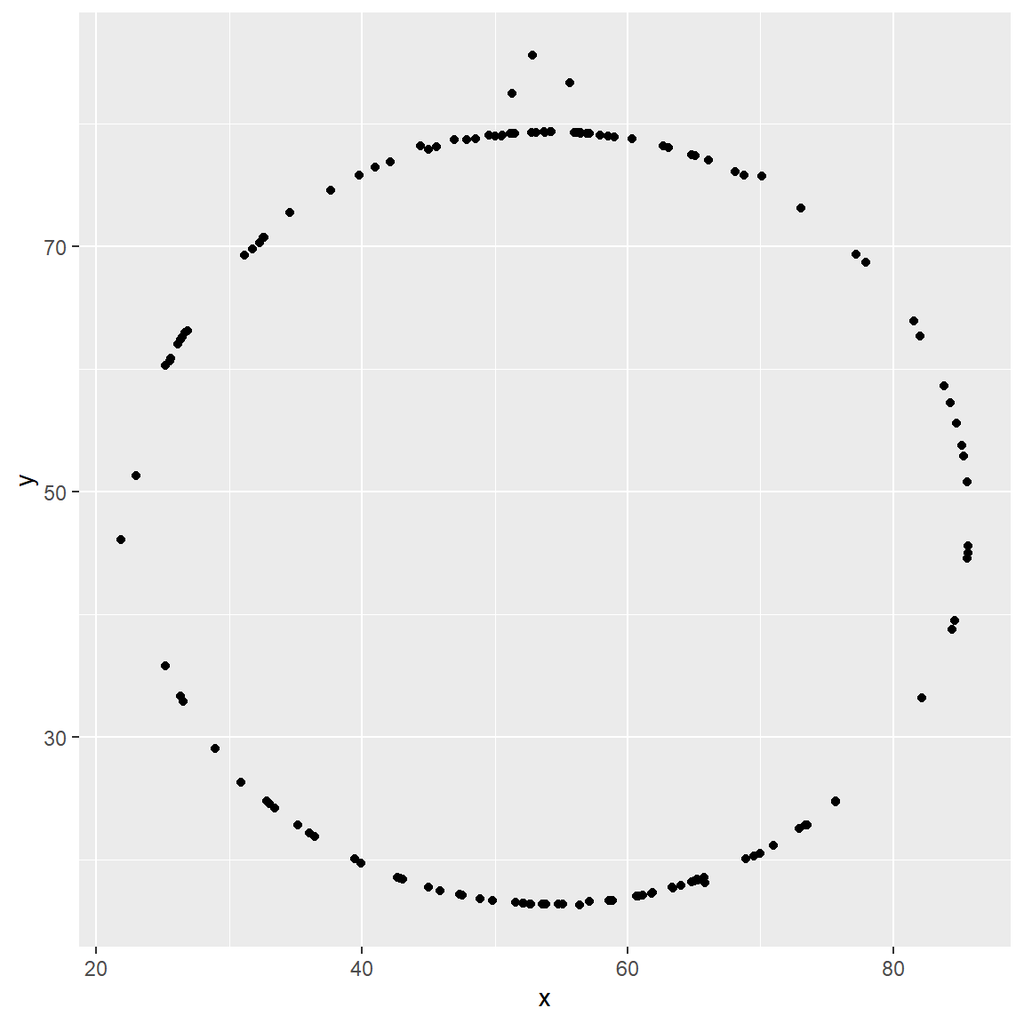

```r
circle_data <- datasaurus_dozen %>%
  filter(dataset == "circle")
ggplot(data = circle_data, aes(x = x, y = y)) +
  geom_point()
```

```r
circle_data %>%
  summarize(r = cor(x, y))
```

```
## # A tibble: 1 × 1
##         r
##     <dbl>
## 1 -0.0683
```

### Comparison of “Circle” dataset with the “Dino” dataset:

As observed earlier, the correlation values for both datasets are close to 0, indicating little to no linear relationship. However, their shapes are drastically different: - The “dino” dataset forms a **dinosaur shape**. - The “circle” dataset forms a **circular pattern**, which inherently has no linear trend.

This reinforces the importance of **visualizing data** rather than relying solely on correlation coefficients, as different distributions can have the same summary statistics.

### Exercise 5

let’s plot all datasets at once and calculate their summary correlation coefficients.

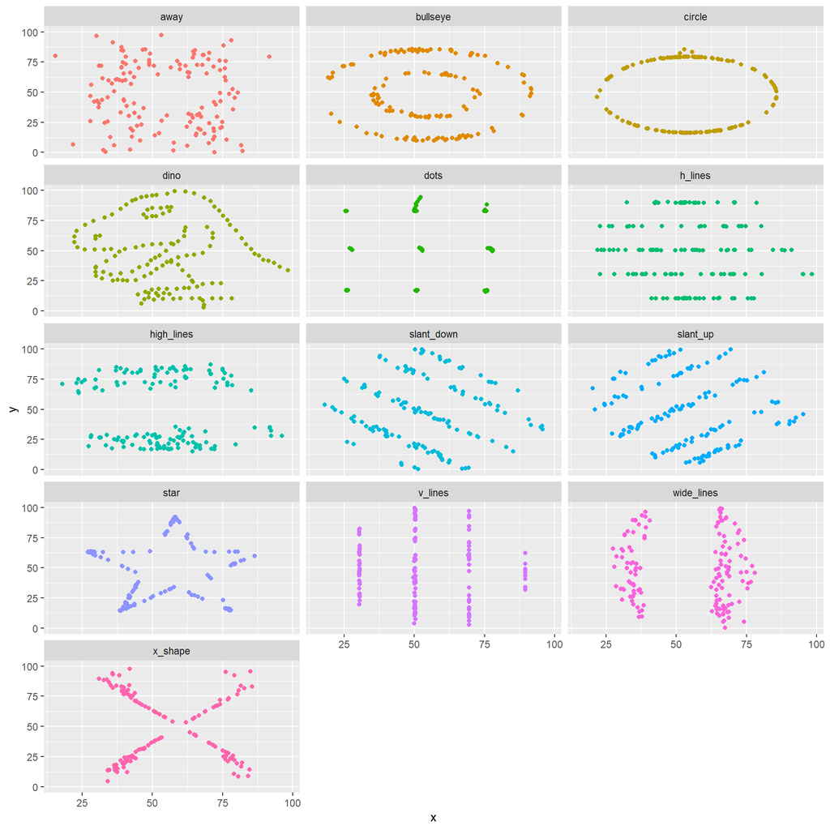

```r
ggplot(datasaurus_dozen, aes(x = x, y = y, color = dataset))+
  geom_point()+
  facet_wrap(~ dataset, ncol = 3) + # facet the dataset variable, in 3 cols
  theme(legend.position = "none")
```

Finally, generating all the summary correlation coefficients:

```r
datasaurus_dozen %>%
  group_by(dataset) %>%
  summarize(r = cor(x, y))
```

```
## # A tibble: 13 × 2
##    dataset          r
##    <chr>        <dbl>
##  1 away       -0.0641
##  2 bullseye   -0.0686
##  3 circle     -0.0683
##  4 dino       -0.0645
##  5 dots       -0.0603
##  6 h_lines    -0.0617
##  7 high_lines -0.0685
##  8 slant_down -0.0690
##  9 slant_up   -0.0686
## 10 star       -0.0630
## 11 v_lines    -0.0694
## 12 wide_lines -0.0666
## 13 x_shape    -0.0656
```